# EDA with White wine Quality Dataset by VISHAL VIKRAM SINGH

# INTRODUCTION

This dataset is related to the white wine of Portuguese version of “Vinho Verde”.Here we will apply Exploratory data analysis in order to find out any influence of the chemical properties of wine over the quality of wine which is ranked from 0(very bad) to 9 (very good).

Summary of Data

```
## [1] 4898   13
```

```
## 'data.frame':    4898 obs. of  13 variables:
##  $ X                   : int  1 2 3 4 5 6 7 8 9 10 ...
##  $ fixed.acidity       : num  7 6.3 8.1 7.2 7.2 8.1 6.2 7 6.3 8.1 ...
##  $ volatile.acidity    : num  0.27 0.3 0.28 0.23 0.23 0.28 0.32 0.27 0.3 0.22 ...
##  $ citric.acid         : num  0.36 0.34 0.4 0.32 0.32 0.4 0.16 0.36 0.34 0.43 ...
##  $ residual.sugar      : num  20.7 1.6 6.9 8.5 8.5 6.9 7 20.7 1.6 1.5 ...
##  $ chlorides           : num  0.045 0.049 0.05 0.058 0.058 0.05 0.045 0.045 0.049 0.044 ...
##  $ free.sulfur.dioxide : num  45 14 30 47 47 30 30 45 14 28 ...
##  $ total.sulfur.dioxide: num  170 132 97 186 186 97 136 170 132 129 ...
##  $ density             : num  1.001 0.994 0.995 0.996 0.996 ...
##  $ pH                  : num  3 3.3 3.26 3.19 3.19 3.26 3.18 3 3.3 3.22 ...
##  $ sulphates           : num  0.45 0.49 0.44 0.4 0.4 0.44 0.47 0.45 0.49 0.45 ...
##  $ alcohol             : num  8.8 9.5 10.1 9.9 9.9 10.1 9.6 8.8 9.5 11 ...
##  $ quality             : int  6 6 6 6 6 6 6 6 6 6 ...
```

```
##        X        fixed.acidity    volatile.acidity  citric.acid
##  Min.   :   1   Min.   : 3.800   Min.   :0.0800   Min.   :0.0000
##  1st Qu.:1225   1st Qu.: 6.300   1st Qu.:0.2100   1st Qu.:0.2700
##  Median :2450   Median : 6.800   Median :0.2600   Median :0.3200
##  Mean   :2450   Mean   : 6.855   Mean   :0.2782   Mean   :0.3342
##  3rd Qu.:3674   3rd Qu.: 7.300   3rd Qu.:0.3200   3rd Qu.:0.3900
##  Max.   :4898   Max.   :14.200   Max.   :1.1000   Max.   :1.6600
##  residual.sugar     chlorides       free.sulfur.dioxide
##  Min.   : 0.600   Min.   :0.00900   Min.   :  2.00
##  1st Qu.: 1.700   1st Qu.:0.03600   1st Qu.: 23.00
##  Median : 5.200   Median :0.04300   Median : 34.00
##  Mean   : 6.391   Mean   :0.04577   Mean   : 35.31
##  3rd Qu.: 9.900   3rd Qu.:0.05000   3rd Qu.: 46.00
##  Max.   :65.800   Max.   :0.34600   Max.   :289.00
##  total.sulfur.dioxide    density             pH          sulphates
##  Min.   :  9.0        Min.   :0.9871   Min.   :2.720   Min.   :0.2200
##  1st Qu.:108.0        1st Qu.:0.9917   1st Qu.:3.090   1st Qu.:0.4100
##  Median :134.0        Median :0.9937   Median :3.180   Median :0.4700
##  Mean   :138.4        Mean   :0.9940   Mean   :3.188   Mean   :0.4898
##  3rd Qu.:167.0        3rd Qu.:0.9961   3rd Qu.:3.280   3rd Qu.:0.5500
##  Max.   :440.0        Max.   :1.0390   Max.   :3.820   Max.   :1.0800
##     alcohol         quality
##  Min.   : 8.00   Min.   :3.000
##  1st Qu.: 9.50   1st Qu.:5.000
##  Median :10.40   Median :6.000
##  Mean   :10.51   Mean   :5.878
##  3rd Qu.:11.40   3rd Qu.:6.000
##  Max.   :14.20   Max.   :9.000
```

# DISTRIBUTION OF SINGLE VARIABLES

## 1.QUALITY

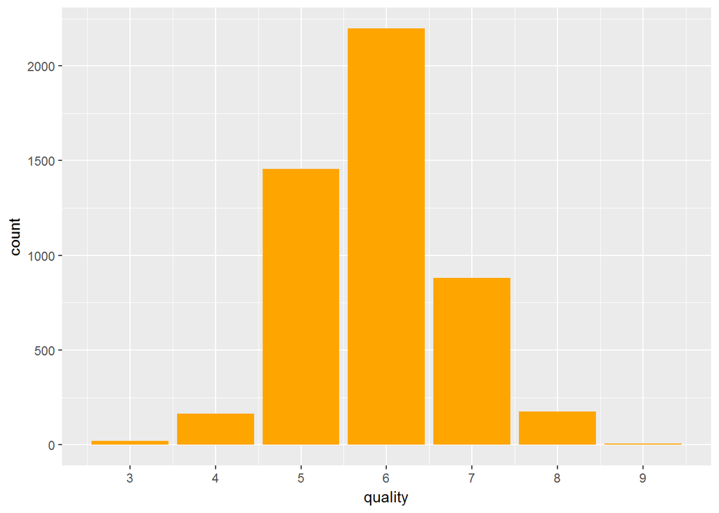

We can see that most of the wines are of quality rating 6. Very small number of wines are rated 9. We have very small number of top quality rated wines in the dataset.

## 2.ALCOHOL

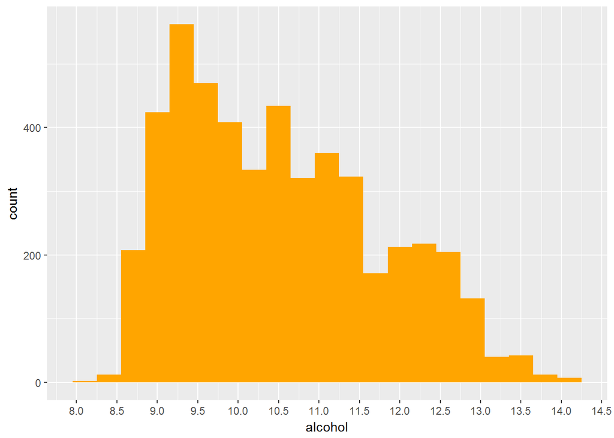

## 3.RESIDUAL SUGAR

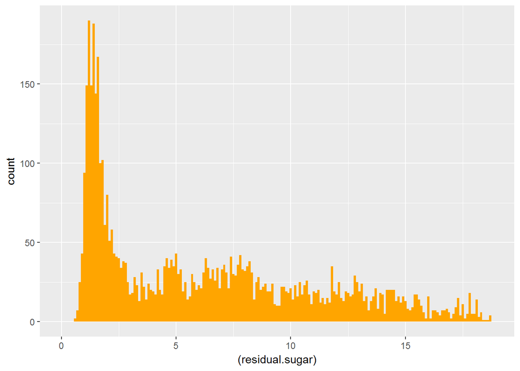

Here we can see that distribution of residual sugar across the wine dataset is skewed . We can apply some transformations to investigate it further.

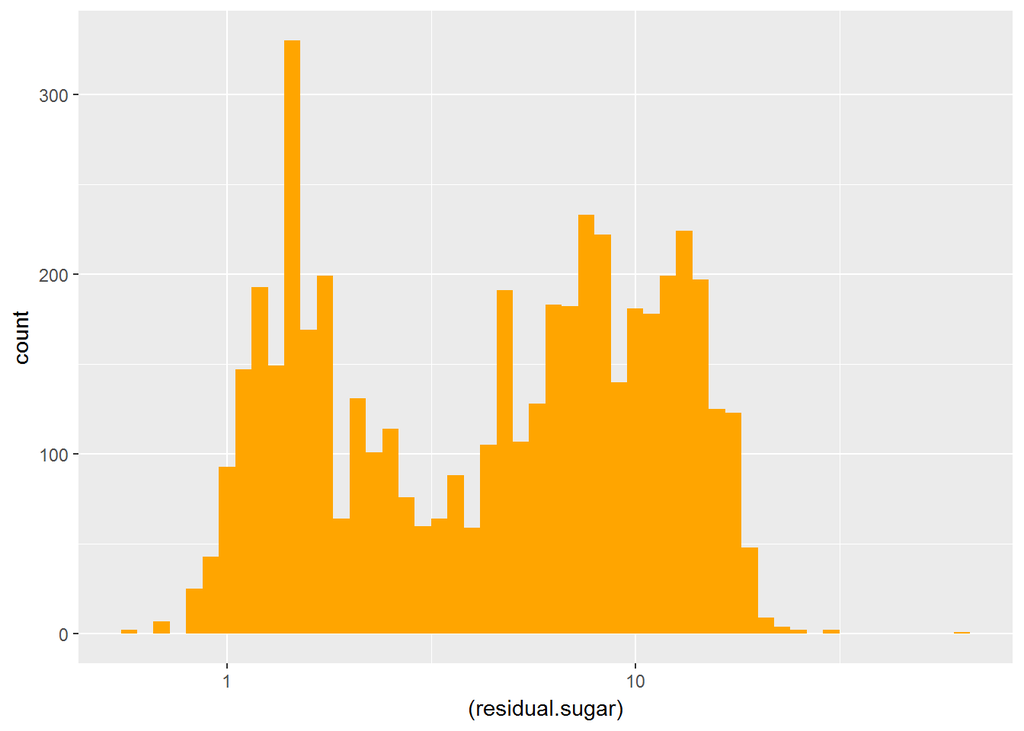

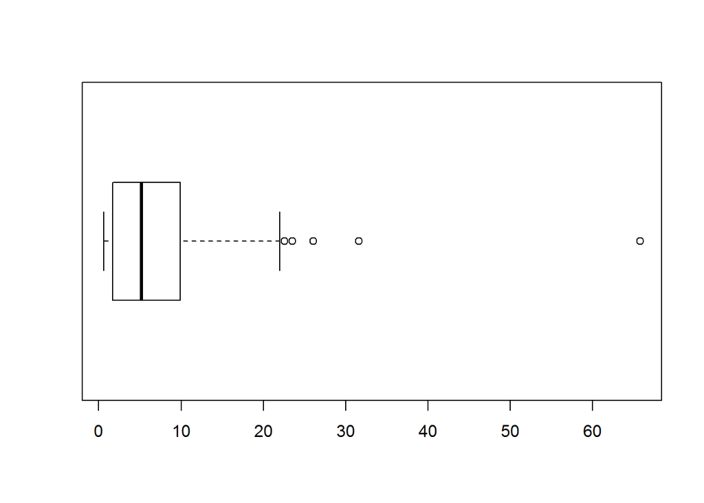

Here we can see that there are some outlier values. We will exclude them from our further analysis.Lets plot the distribution of residual sugar excluding the outliers:

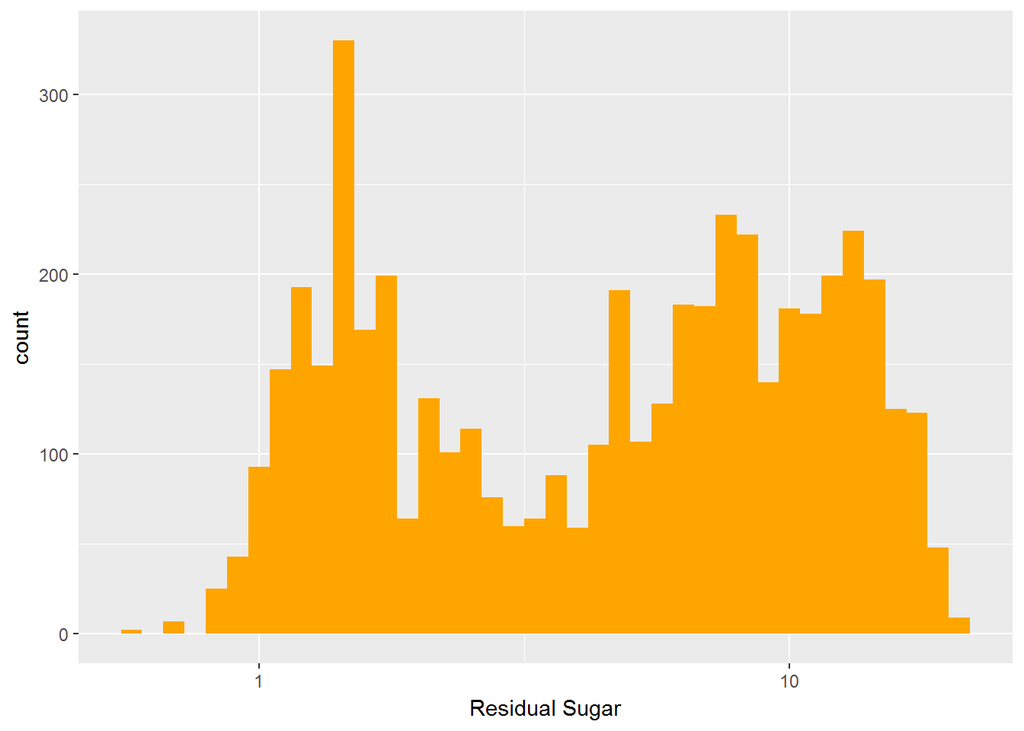

## 4.CITRIC ACID

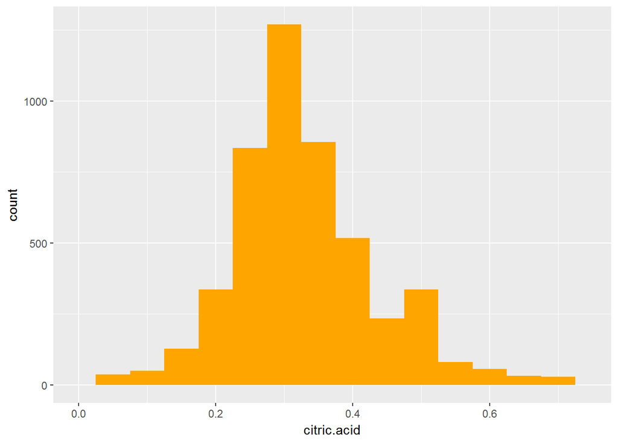

Again ,its observed that distribution of citric acid follows normal distribution with peaking around 0.3 .

## 5.VOLATILE ACIDITY

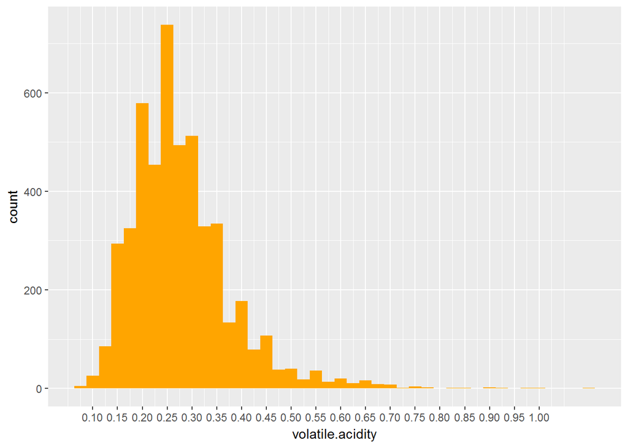

From the histogram we can observe that most of the values lies under 0.6 . Lets check for outliers using boxplot:

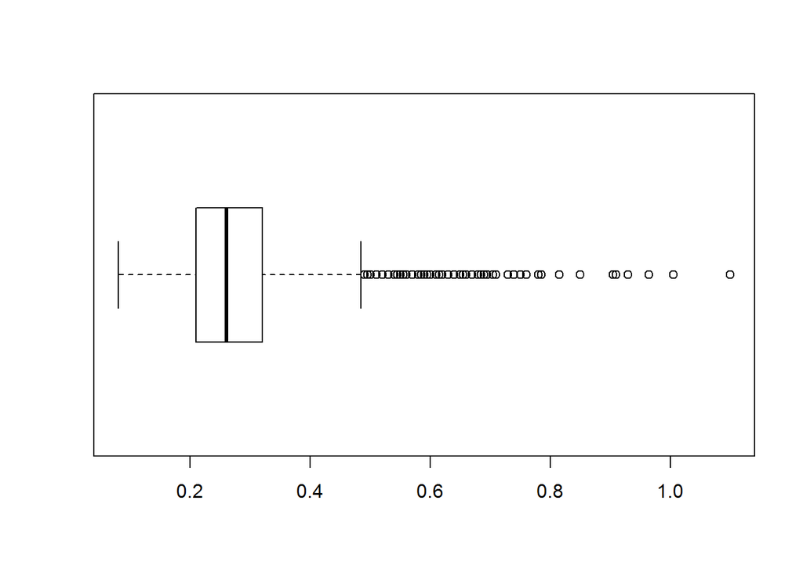

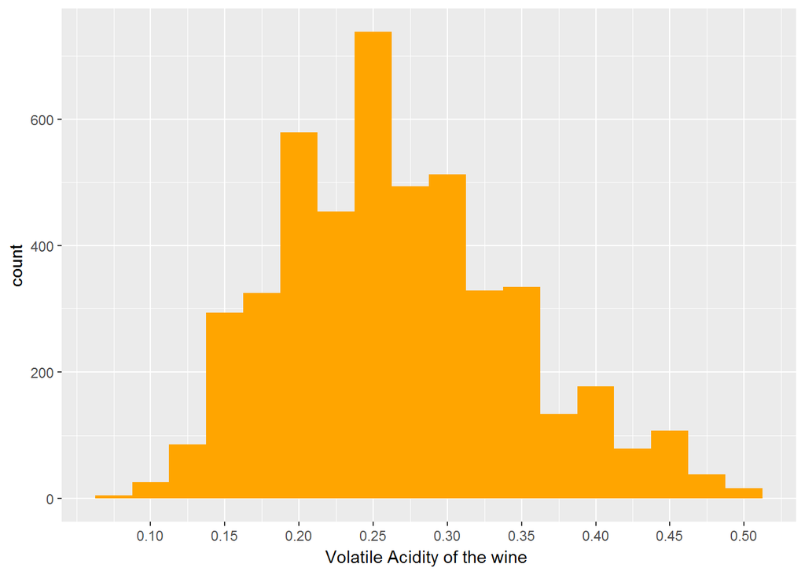

After removing outliers the distribution of volatile acidity follows the normal distribution with peak around 0.25 .

## 6.FREE SULPHUR DIOXIDE

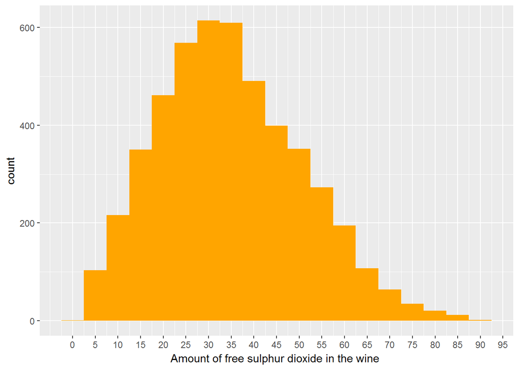

it also follows the normal distribution after removing the outliers.

## 7.DENSITY

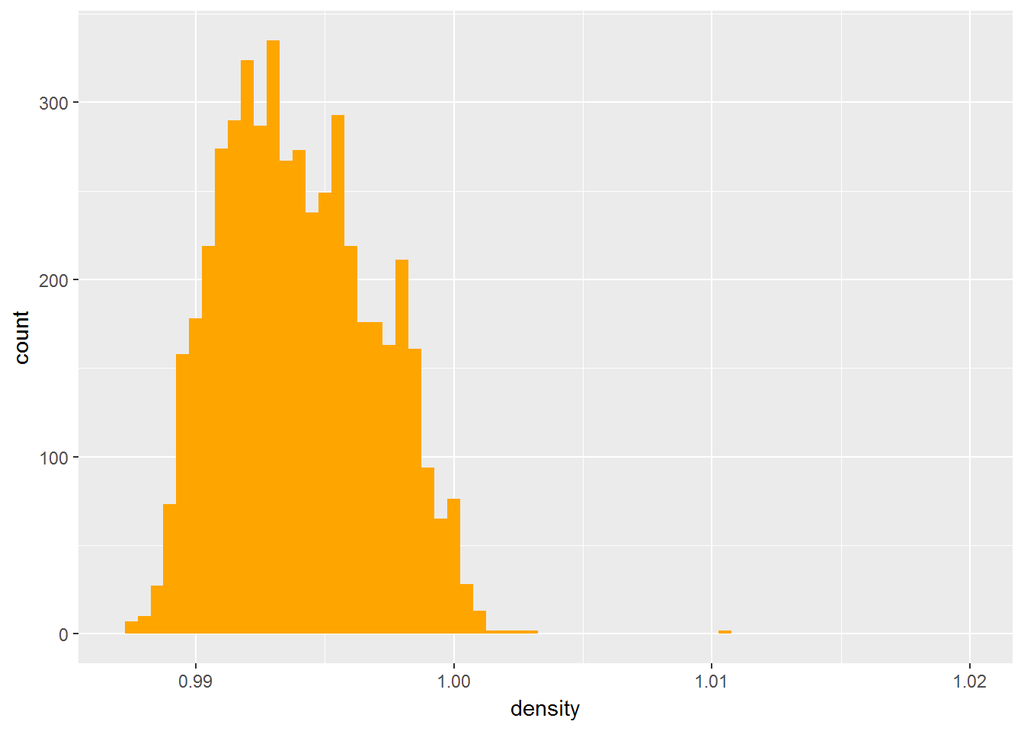

Here we can see that most of the wines have density falling between 0.98 and 1. We can explore outliers using boxplot as follows:

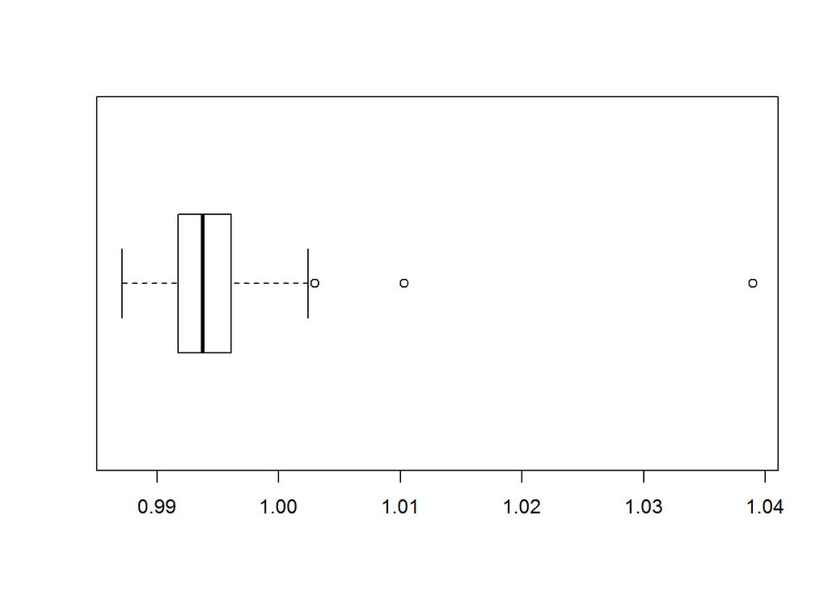

We can clearly see three outliers in the distribution of density across wine quality dataset. Lets remove them and plot histogram for density variable:

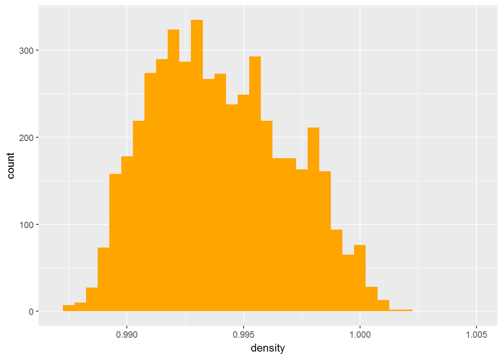

Now we have a roughly normal distribution curve for density.

## 8.pH of wine

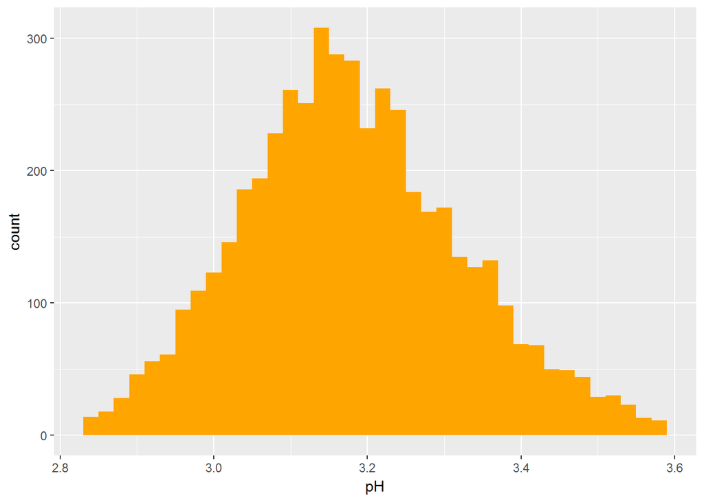

Again we can see normal shape of the distribution . Most of the wines have pH around 3.2 .

## 9.CHLORIDES

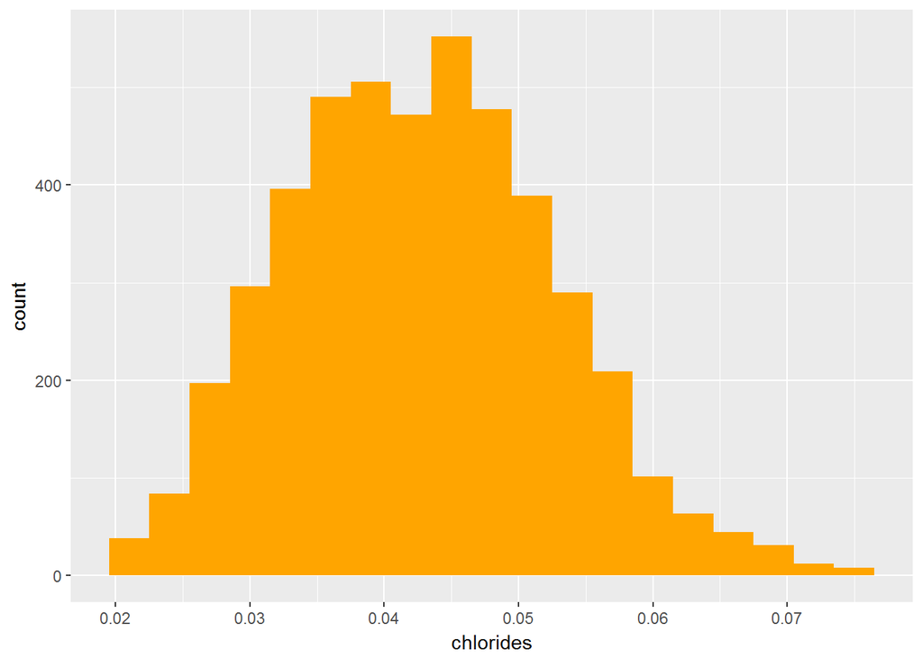

Again the distribution of chlorides is roughly normal.

## 10.SULPHATES

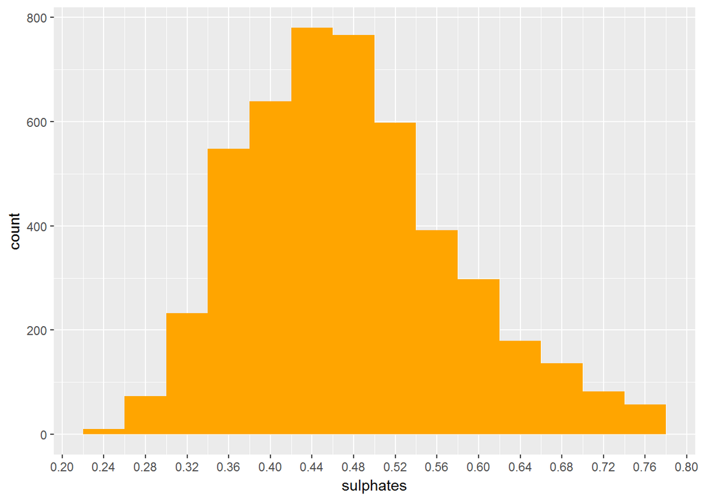

```r
ggplot(aes(x=sulphates),data=subset(wine,wine$sulphates<0.78))+
  geom_histogram(fill="orange",binwidth = 0.04)+
  scale_x_continuous(breaks = seq(0.2,0.8,0.04))
```

Most of the wines have sulphate content value around 0.46 .

# UNIVARIATE ANALYSIS

### Q.What are the main features of interest in your dataset ?

the main feature of interest in our dataset is alcohol and quality .I would like to determine how the quantity of alcohol in the wine affects its quality .

### Q.What other features in the dataset do you think will help support your investigation into your feature of interest ?

I think other features like pH , citirc Acid would also affect the quality of the wine .

### Q.Of the features you investigated, were there any unusual distributions? Did you perform any operations on the data to tidy, adjust, or change the form of the data? If so, why did you do this?

I log transformed the skewed- distribution of residual sugar to get more even distribution of the data. After transformation bimodal curve is obtained .I also removed some outliers from the data before applying transformation.

# BIVARIATE PLOTTING

## 1.CORRELATION MATRIX

```
##                                 X fixed.acidity volatile.acidity
## X                     1.000000000   -0.25581431      0.002857966
## fixed.acidity        -0.255814305    1.00000000     -0.022697290
## volatile.acidity      0.002857966   -0.02269729      1.000000000
## citric.acid          -0.149899918    0.28918070     -0.149471811
## residual.sugar        0.006623775    0.08902070      0.064286060
## chlorides            -0.045645192    0.02308564      0.070511571
## free.sulfur.dioxide  -0.011928911   -0.04939586     -0.097011939
## total.sulfur.dioxide -0.161979037    0.09106976      0.089260504
## density              -0.185976097    0.26533101      0.027113845
## pH                   -0.115774132   -0.42585829     -0.031915368
## sulphates             0.009807759   -0.01714299     -0.035728147
## alcohol               0.213656245   -0.12088112      0.067717943
## quality               0.035763247   -0.11366283     -0.194722969
##                       citric.acid residual.sugar   chlorides
## X                    -0.149899918    0.006623775 -0.04564519
## fixed.acidity         0.289180698    0.089020701  0.02308564
## volatile.acidity     -0.149471811    0.064286060  0.07051157
## citric.acid           1.000000000    0.094211624  0.11436445
## residual.sugar        0.094211624    1.000000000  0.08868454
## chlorides             0.114364448    0.088684536  1.00000000
## free.sulfur.dioxide   0.094077221    0.299098354  0.10139235
## total.sulfur.dioxide  0.121130798    0.401439311  0.19891030
## density               0.149502571    0.838966455  0.25721132
## pH                   -0.163748211   -0.194133454 -0.09043946
## sulphates             0.062330940   -0.026664366  0.01676288
## alcohol              -0.075728730   -0.450631222 -0.36018871
## quality              -0.009209091   -0.097576829 -0.20993441
##                      free.sulfur.dioxide total.sulfur.dioxide     density
## X                          -0.0119289106         -0.161979037 -0.18597610
## fixed.acidity              -0.0493958591          0.091069756  0.26533101
## volatile.acidity           -0.0970119393          0.089260504  0.02711385
## citric.acid                 0.0940772210          0.121130798  0.14950257
## residual.sugar              0.2990983537          0.401439311  0.83896645
## chlorides                   0.1013923521          0.198910300  0.25721132
## free.sulfur.dioxide         1.0000000000          0.615500965  0.29421041
## total.sulfur.dioxide        0.6155009650          1.000000000  0.52988132
## density                     0.2942104109          0.529881324  1.00000000
## pH                         -0.0006177961          0.002320972 -0.09359149
## sulphates                   0.0592172458          0.134562367  0.07449315
## alcohol                    -0.2501039415         -0.448892102 -0.78013762
## quality                     0.0081580671         -0.174737218 -0.30712331
##                                 pH    sulphates     alcohol      quality
## X                    -0.1157741316  0.009807759  0.21365624  0.035763247
## fixed.acidity        -0.4258582910 -0.017142985 -0.12088112 -0.113662831
## volatile.acidity     -0.0319153683 -0.035728147  0.06771794 -0.194722969
## citric.acid          -0.1637482114  0.062330940 -0.07572873 -0.009209091
## residual.sugar       -0.1941334540 -0.026664366 -0.45063122 -0.097576829
## chlorides            -0.0904394560  0.016762884 -0.36018871 -0.209934411
## free.sulfur.dioxide  -0.0006177961  0.059217246 -0.25010394  0.008158067
## total.sulfur.dioxide  0.0023209718  0.134562367 -0.44889210 -0.174737218
## density              -0.0935914935  0.074493149 -0.78013762 -0.307123313
## pH                    1.0000000000  0.155951497  0.12143210  0.099427246
## sulphates             0.1559514973  1.000000000 -0.01743277  0.053677877
## alcohol               0.1214320987 -0.017432772  1.00000000  0.435574715
## quality               0.0994272457  0.053677877  0.43557472  1.000000000
```

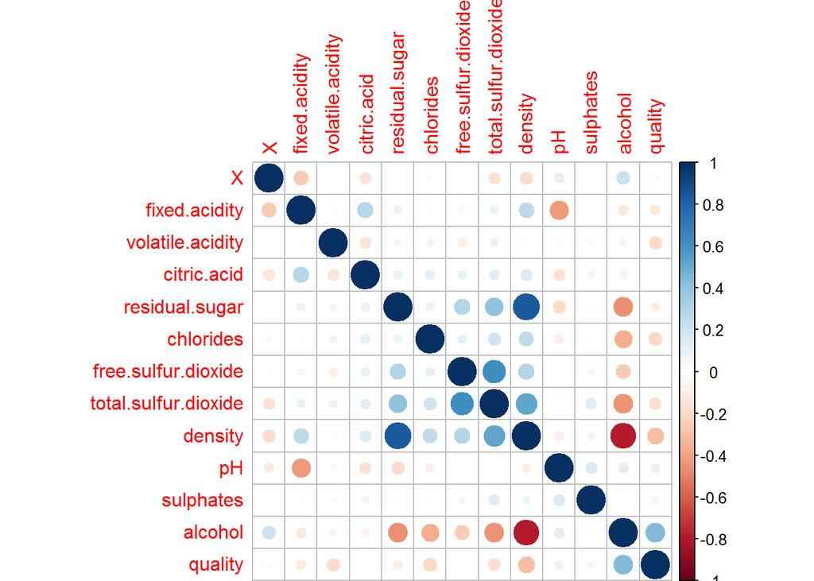

From the coorelation matrix plot we can see that quality and alcohol have comapratively strong value of pearsons r .We will further investigae it by plotting them against each other.I have plotted some other variables of interest in the following section:

## 2.QUALITY VS ALCOHOL

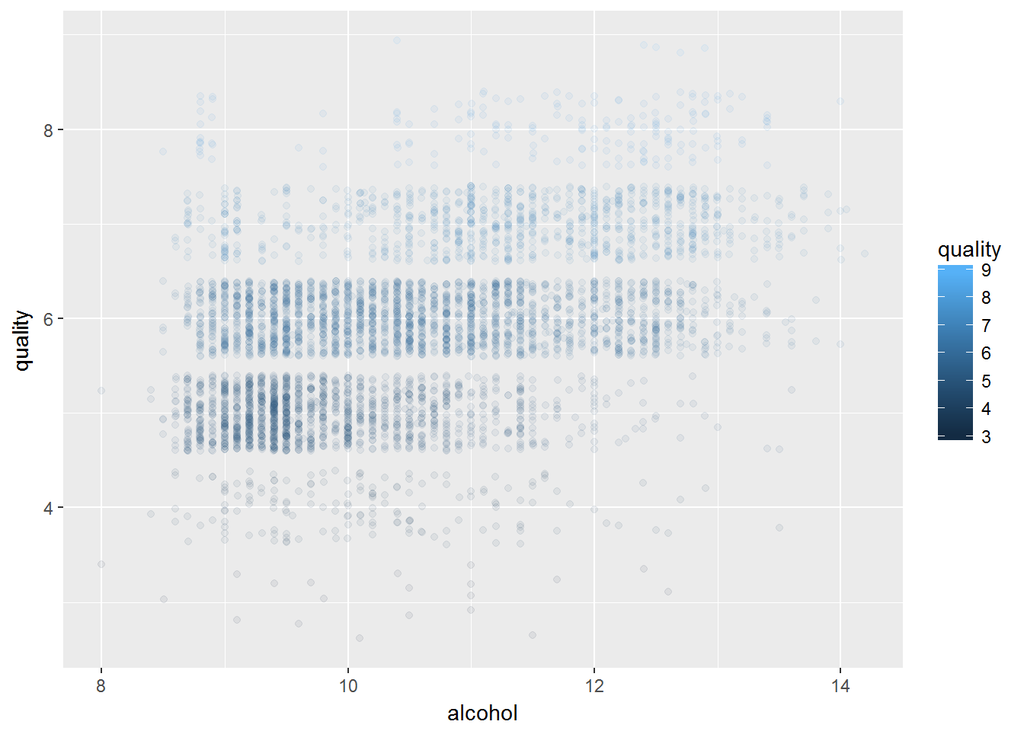

As we can see that as quality increase alcohol content also increase .

## 3.QUALITY VS VOLATILE ACIDITY

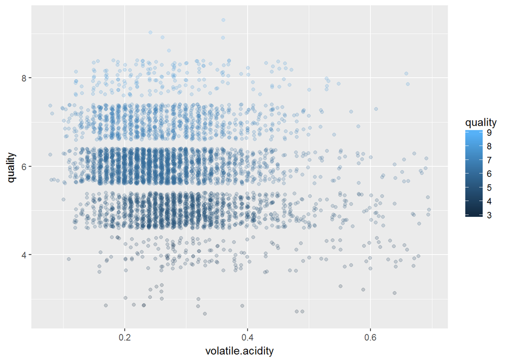

Here we can see that wine with higher quality rating tend to have smaller volatile Acidity .

## 4.QUALITY VS DENSITY

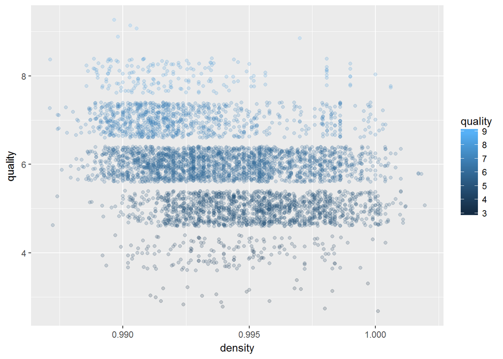

Again there appears to be some relationship between density and qualty as higher quality wine tend to have comparatively lower density .Although it was not our main feature of interest but after plotting the correlation matrix we saw some evidence of this relationship.

## 5.QUALITY VS CHLORIDES

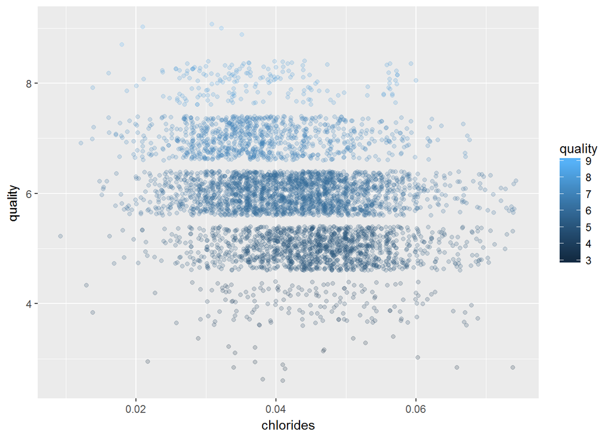

# Bivariate Analysis

From the coorelation matrix it is evident that quality and alcohol have strong relationship as compared to other variables. This strengthened out assumption .After plotting alcohol vs quality on scatterplot we can cearly see some trends.Higher quality wines tend to have higher alcohol quantity.

I also observed some interesting relationship between qualty and density which was not part of our initial assumption. Volatile acidity and quality also showed some negative relationship.

The strongest relationship i found was between alcohol and quality.

# MULTIVARIATE PLOTs

## 1.ALCOHOL VS VOLATILE ACIDITY AND QUALTY

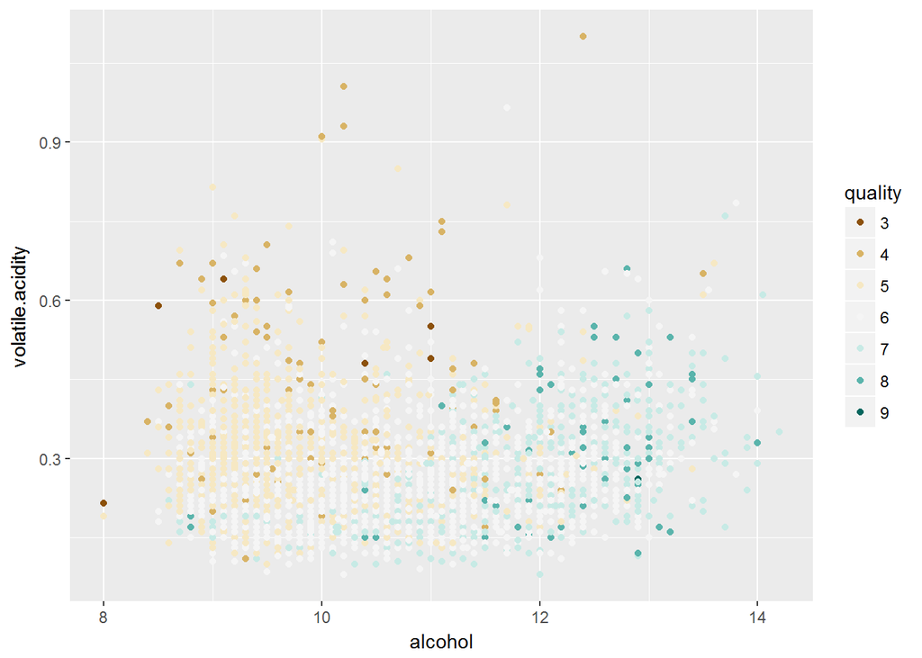

Here we can observe that wine with higer quality rating tends to have higher alcohol percentage and lesser volatile Acidity .

## 2.ALCOHOL VS DENSITY AND QUALITY AS COLOR

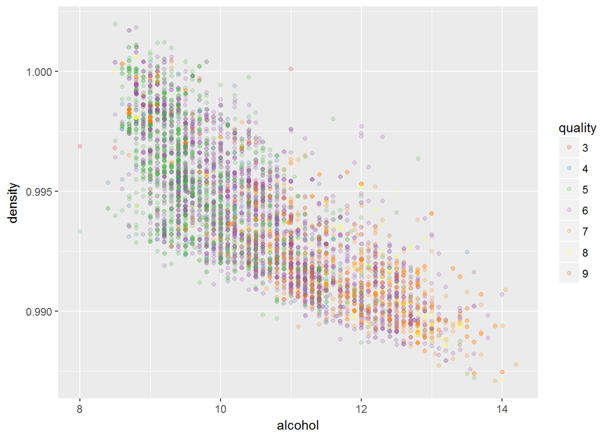

Here again we can see that wine with higher rating tends to have lower density and higher alcohol content.

# FINAL PLOTS AND SUMMARY

## PLOT ONE

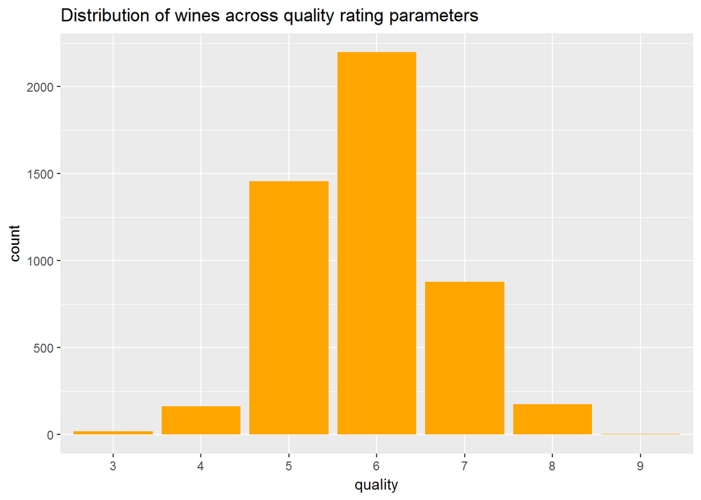

Above plot shows the distribution of observations from dataset across different quality parameter ranked by the experts.We can see that most of the wines have quality rating of 6.

## PLOT TWO

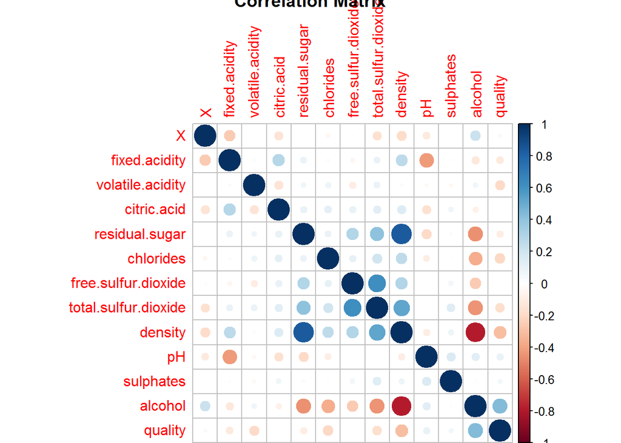

Above plot shows the correlation coefficient between each pair of attributes.It can be observed that quality has high correlation coefficient with alcohol.

## 2.PLOT TWO

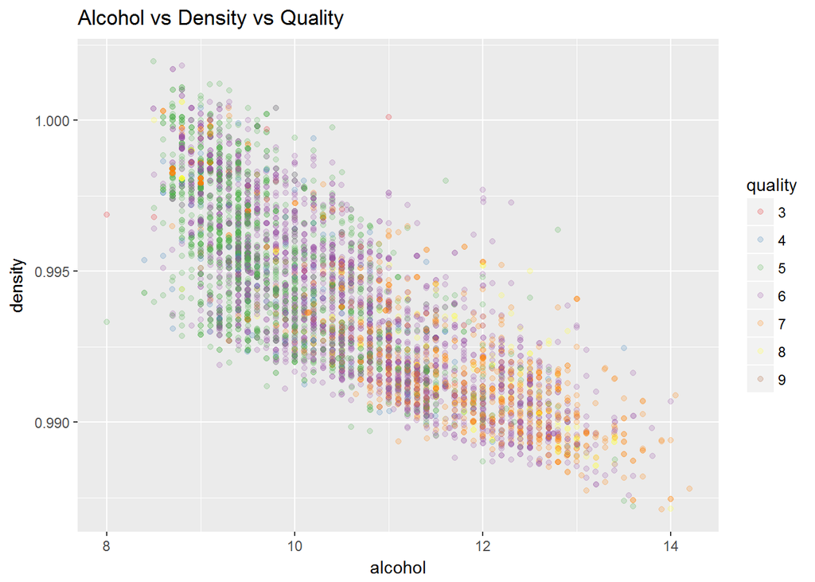

Our final plot represents that higher quality wines have high alcohol content and lesser density.

# REFLECTION

From exploratory data analysis of white wine quality dataset it can be inferred that higher quality wine tends to have higher alcohol content . As per our assumption i find out the relationship between quality and alcohol content. I also found that higher quality wines have lesser density as compared to lower quality wines. So density and alcohol content is the crucial factor to consider in order to make good wines.